# Reproducible Research - Week 2 Assignment

Juan

August 16, 2016

This R Markdown document is the submission for the week 2 assignment of the Coursera *Reproducible Research" class.

**Note: All figures are embedded in the resulting html document**

### Section 1 - Data input

The following section of code clears the memory, loads the desired libraries and reads in the data file *active.csv* and stores it in the data frame **Data_Raw.**

```r
options(warn = -1)      # Suppress warnings
rm(list=ls()) # Clear memory
library(ggplot2, quietly = TRUE)
Data_Raw <- read.csv("activity.csv", sep = ",", header = TRUE)  # Read data file
```

### Section 2 - Histogram of total steps

The following section creates the first histogram plot. The code performs the frequencyt calculation using the *aggregate* function:

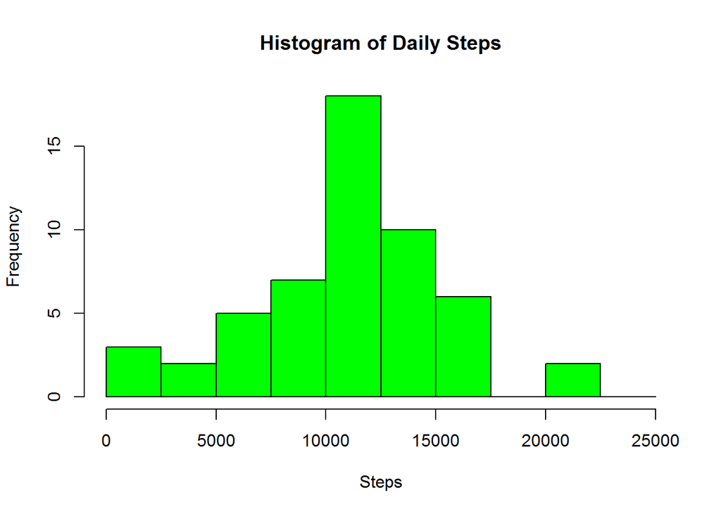

```r
steps <- aggregate(Data_Raw$steps,by=list(Data_Raw$date),sum)
b <- seq(0,25000,by=2500)
hist(steps[,2],xlab="Steps",main="Histogram of Daily Steps",breaks=b,col="green")
```

### Section 3 - Mean and median number of steps by day

The following section calculates both the mean and median number of steps for each day in the data. As in section 2, the aggregate function is used to break the data up according to the date variable. Because that function converts the date data to factor, a call to *as.Date* is needed to convert the data back to date format.

A final call to the *head* function is used to print just the first few lines of data.

```r
ave_steps <- aggregate(Data_Raw$steps,by=list(Data_Raw$date),mean)  # Compute average steps by day
med_steps <- aggregate(Data_Raw$steps,by=list(Data_Raw$date),median) # Compute median steps by day
names(ave_steps) <- c("Date","Mean")    # Assign column names to both data frames
names(med_steps) <- c("Date","Median")
combined <- merge(ave_steps,med_steps, by.x = "Date", by.y = "Date")   # Merge the two data frames
combined$Date <- as.Date(combined$Date, "%m/%d/%Y")   # Comvert first column to "date" format
new_combined <- combined[order(combined$Date),] # Sort by date
head(new_combined)
```

```
##          Date     Mean Median
## 1  2012-10-01       NA     NA
## 12 2012-10-02  0.43750      0
## 23 2012-10-03 39.41667      0
## 26 2012-10-04 42.06944      0
## 27 2012-10-05 46.15972      0
## 28 2012-10-06 53.54167      0
```

### Section 4 - Time series plot of mean number of steps per day

The previous section already prepared the data into the right format in the *new_combined* data frame so creating a plot is just a simple call to *ggplot*.

**Note: warnings for missing points are not suppressed**

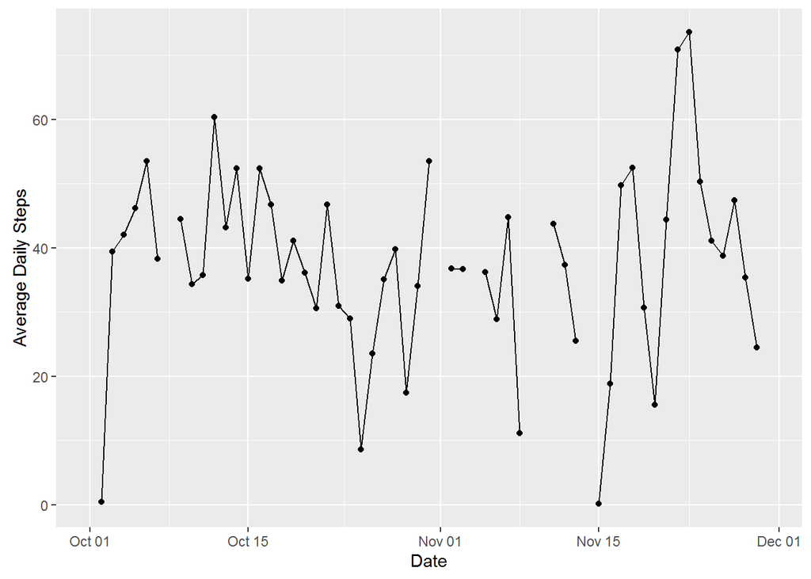

```r
chart <- ggplot(data = new_combined, aes(x = Date, y = Mean)) + geom_line() + geom_point()+ labs(x = "Date", y = "Average Daily Steps")
print(chart)
```

### Section 4 - Five-minute time interval with the highest average steps

Once more, the *aggregate* function is used but this time with the variable *interval* as the groupng variable. For this particular calculation, all **NA’s** are removed.

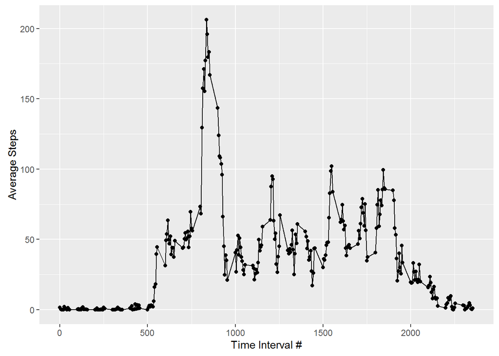

[output not shown]

```r
steps_int <- aggregate(Data_Raw$steps,by=list(Data_Raw$interval),mean,na.rm=TRUE)  # Compute averages
imax <- which.max(steps_int$x)  # Index of interval with highest average step count
chart <- ggplot(data = steps_int, aes(x = Group.1, y = x)) + geom_line() + geom_point()+ labs(x = "Time Interval #", y = "Average Steps")
print(chart)        # Create chart
```

### Section 5 - Replace missing values in the data

This section finds all the missing values in the data and replaces them with the average step count for the specific time interval where the data is missing. That data is already stored in the variable **steps_int**. The steps followed are:

- Find the index of all missing values using the functions *which* and *is.na*
- Loop over those indices and replace them with the average for that specific time interval

The new variable with the cleaned up data is **Data_clean**.

```r
Data_clean <- Data_Raw      # Make copy of original data
ina <- which(is.na(Data_Raw$steps)) # Index of missing data
for (i in ina){     # Loop and replace all NA's with average steps for that interval
    Data_clean[i,1] <- steps_int[steps_int$Group.1 == Data_clean[i,3],2]
}
```

### Section 6 - Re-create histograms of daily step count with new data

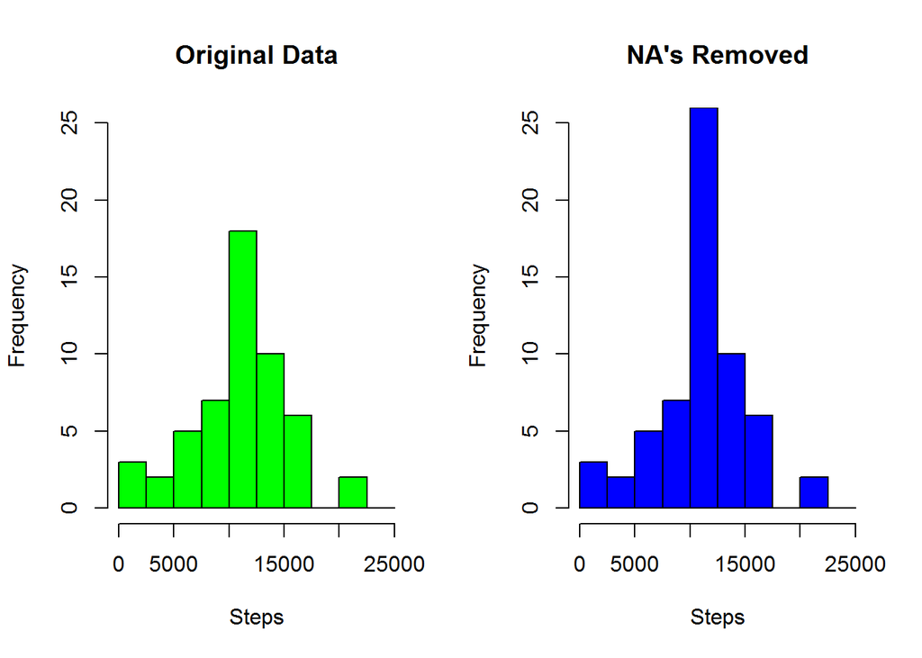

```r
steps_clean <- aggregate(Data_clean$steps,by=list(Data_clean$date),sum)   # New steps totals by day
# Plot the histogram side by side for comparison with the original data
par(mfrow = c(1,2))
hist(steps[,2],xlab="Steps",main="Original Data",breaks=b,col="green", ylim = c(0,25))
hist(steps_clean[,2], xlab="Steps",main="NA's Removed",breaks=b,col="blue", ylim = c(0,25))
```

### Section 7 - Comparison of steps taken on weekdays versus weekends

This section creates a panel plot to compare the steps taken, as a function of time, between weekdays and weekends. The data used is the one with the NA’s removed. The procedure is:

- Create a varibale that classifies all the dates as either weekdays or weekends. The main workhorse for this is the function *weekdays()*
- Use that variable to subset the data for weekdays and weekends
- Use the *aggregate* function again to calculate mean step counts for each time interval
- Plot the results side by side for comparison

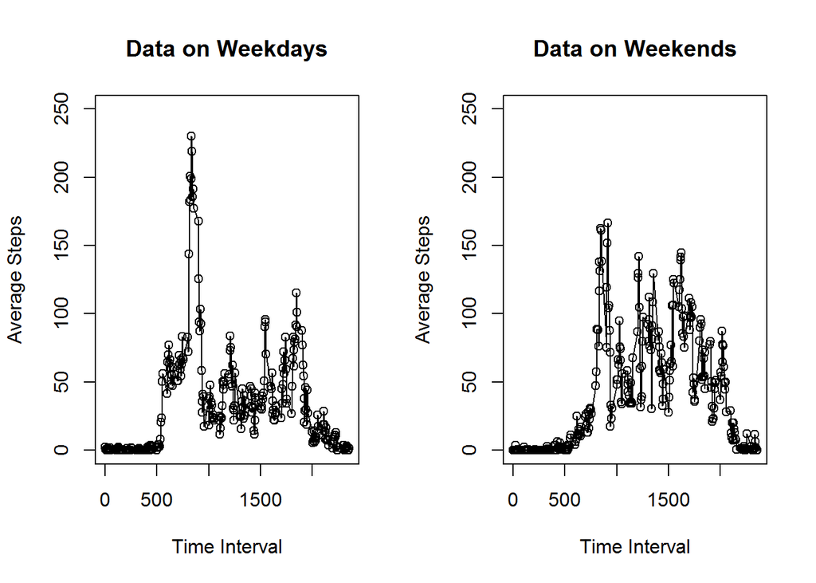

```r
fact <- ifelse(weekdays(as.Date(Data_clean$date,"%m/%d/%Y")) %in% c("Saturday","Sunday"), "Weekend", "Weekday")
Data_wkd <- Data_clean[fact == "Weekday",]  # Data subset for weekdays
Data_wke <- Data_clean[fact == "Weekend",]  # Data subset for weekends
steps_wkd <- aggregate(Data_wkd$steps,by=list(Data_wkd$interval),mean)   # New steps totals for week days
steps_wke <- aggregate(Data_wke$steps,by=list(Data_wke$interval),mean)  # New steps totals for week ends
par(mfrow = c(1,2))
plot(steps_wkd,xlab="Time Interval",ylab="Average Steps",main="Data on Weekdays", ylim = c(0,250))
lines(steps_wkd)
plot(steps_wke,xlab="Time Interval",ylab="Average Steps",main="Data on Weekends", ylim = c(0,250))
lines(steps_wke)
```